# Homework 7: Strings + Logical Vectors (Graphical Perception)

Author

MICR 475/575

## Instructions

In this homework you will practice:

- importing a Google Forms CSV export
- working with **strings**
- building and using **logical vectors**
- making data tidy with `pivot_longer()`
- making a simple **box plot**

You will work with a Google Forms CSV export from our in-class graphical perception experiment.

## Setup

```r
library(tidyverse)

csv_path <- "(data/handb_ptest.csv)"
```

# Q1. Import the data

**Task:** Read the CSV into an object called `raw`, then preview it.

```r
#
library(readr)

raw <- read.csv("E:/phd/Year/Spring 2026/wee 7 assignment/r4ds_c10_to_16/data/handb_ptest.csv", na = c("N/A", ""))

head(raw)
```

```
                   Timestamp Which.item.is.SMALLER...A.B.
1 2026/02/26 11:13:42 AM EST                            A
2  2026/02/26 4:43:18 PM EST                            A
3 2026/02/27 12:00:33 PM EST                            A
4 2026/02/27 12:07:28 PM EST                            A
5 2026/02/27 12:11:21 PM EST                            A
6 2026/02/27 12:11:30 PM EST                            A
  The.smaller.is.approximately.___..of.the.larger
1                                              75
2                                              80
3                                             75%
4                                              75
5                                              75
6                                              20
  Which.item.is.SMALLER...A.B..1
```

[output cut: 111 more lines]

## Q2. Tidy the data (Method A: pivot_longer first, then rename question type variable)

In the raw Google Forms export, the response columns have long names that include the full question text. Your goal is a tidy data frame with one row per response, and columns:

- `timestamp`
- `chart_type` (values like `T1`, `T2`, …, `T9`)
- `percent` (numeric)

**Task A:** Start from `raw`, `pivot_longer()` everything *except* `timestamp`.

**Task B:** Convert the `percent` column to a number.

**Task C:** Use **string operations** (and at least one **logical vector**) to convert the messy `chart_type` column into clean labels.

> Hint 1: `parse_number(chart_type)` can pull the number out of the string.  
> Hint 2: A logical vector can help you keep only the question numbers you want.

**Task D:** Make a **box plot** of `percent` by `chart_type` (no log transform).

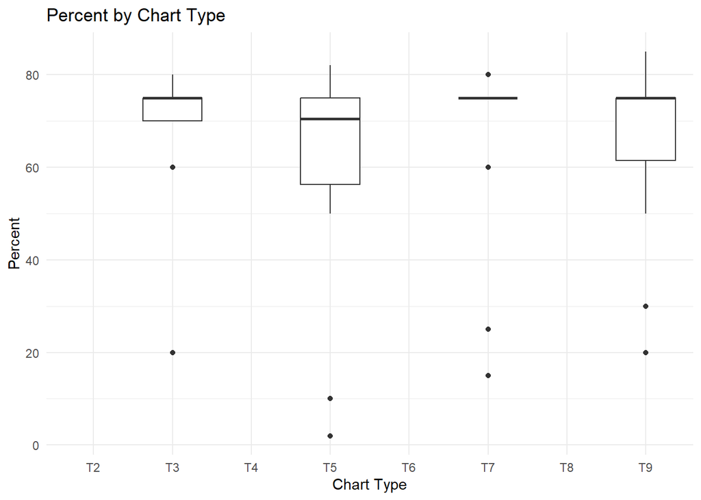

```r
# Load required packages
library(tidyverse)
library(janitor)

# Import the data
raw <- read_csv("E:/phd/Year/Spring 2026/wee 7 assignment/r4ds_c10_to_16/data/handb_ptest.csv", na = c("N/A", "")) %>%
  clean_names()

# Tidy the data
tidy <- raw %>%
  pivot_longer(
    cols = -timestamp,
    names_to = "chart_type",
    values_to = "percent"
  ) %>%
  mutate(
    percent = parse_number(percent),
    qnum = parse_number(chart_type),
    keep = qnum >= 1 & qnum <= 9
  ) %>%
  filter(keep) %>%
  mutate(chart_type = paste0("T", qnum)) %>%
  select(timestamp, chart_type, percent)

# Make the boxplot
ggplot(tidy, aes(x = chart_type, y = percent)) +
  geom_boxplot() +
  labs(
    x = "Chart Type",
    y = "Percent",
    title = "Percent by Chart Type"
  ) +
  theme_minimal()
```